# Hypothesis Testing and Decision Errors

# Decision Errors

[figure not shown]

# The Significance Level and Decisions Errors

**What does this all mean?** When the p-value is small, i.e., less than a previously set threshold ($\alpha$), we say the results are **statistically significant**. The value of $\alpha$ represents how rare an event needs to be in order for the null hypothesis to be rejected. The $\alpha$ also represents the probability of committing a type I error.

| Reality/Decision | **Reject $H_0$** | **Fail to reject $H_0$** |
| --- | --- | --- |
| **$H_0$ is true** | Type I error with probability $\alpha$ (significance level) | Correct decision with probability $1-\alpha$ (confidence level) |
| **$H_0$ is false** | Correct decision with probability $1-\beta$ (power of test) | Type II error with probability $\beta$ |

Conclusion errors: Type I error (false positive) or Type II error (false negative)

# Trade-offs between Type I and Type II errors (1/2)

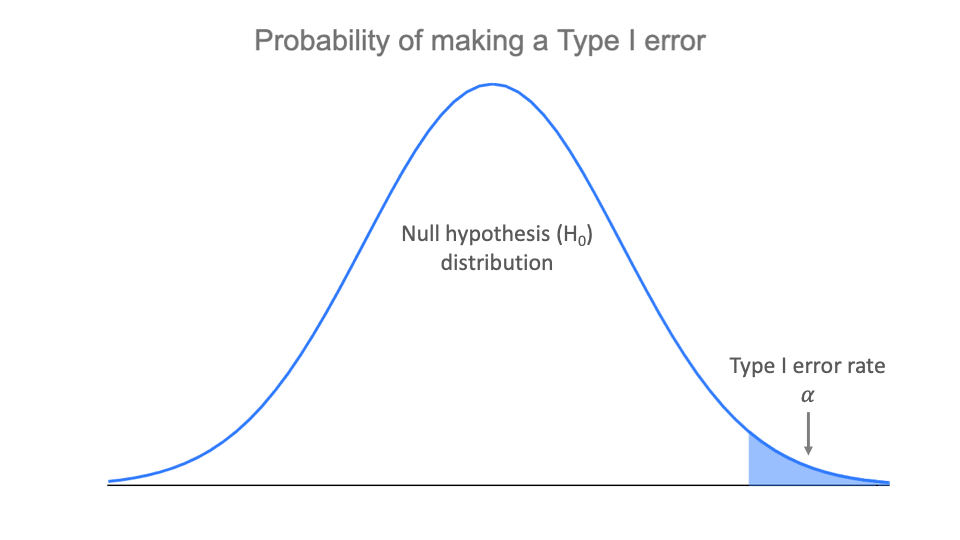

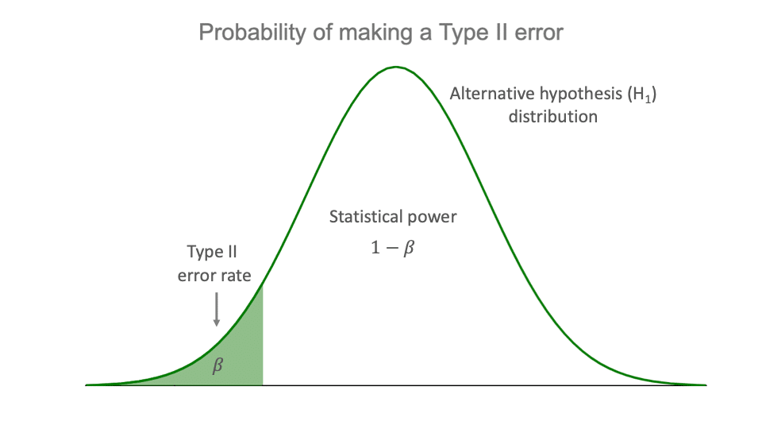

Images Source: [Type I and Type II errors by Pritha Bhandari](https://www.scribbr.com/statistics/type-i-and-type-ii-errors/)

# Trade-offs between Type I and Type II Errors (2/2)

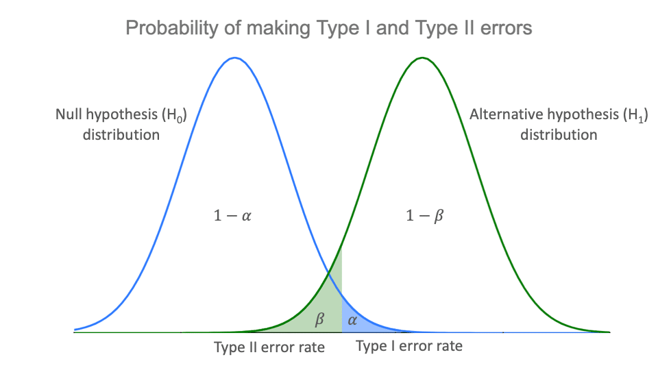

Images Source: [Type I and Type II errors by Pritha Bhandari](https://www.scribbr.com/statistics/type-i-and-type-ii-errors/)

# Example 2

- Question: In a US court, the defendant is either innocent ($H_0$) or guilty ($H_A$). What does a Type I Error represent in this context? What does a Type II Error represent?
- Answer: If the court makes a **Type I Error**, this means the defendant is innocent ($H_0$ is true) but wrongly convicted. A **Type II Error** means the court failed to reject $H_0$ (i.e., failed to convict the person) when they were in fact guilty ($H_A$ true).

# Example 2: Type I error Consequences

**A Type I error occurs when the null hypothesis is incorrectly rejected, leading to a wrongful conviction.**

This means that an innocent person is found guilty and sentenced, possibly facing imprisonment or even capital punishment. The consequences extend beyond the individual, affecting their family, reputation, and future opportunities. Additionally, the real perpetrator remains free, potentially committing further crimes.

# Example 2: Type II error Consequences

**A Type II error occurs when the null hypothesis was failed to reject, leading to a wrongful acquittal.**

This means that a guilty person is found not guilty and released. As a result, justice is not served for the victims, and the criminal may go on to commit additional offenses, putting society at risk. This error can undermine public trust in the legal system, as it fails to hold the guilty accountable.

# Activity: Determine Claims and Error Types

1. Make sure you have a copy of the *M 3/17 Worksheet*. This will be handed out physically and it is also digitally available on Moodle.
2. Work on your worksheet by yourself for 10 minutes. Please read the instructions carefully. Ask questions if anything need clarifications.
3. Get together with another student.
4. Discuss your results.
5. Submit your worksheet on Moodle as a `.pdf` file.

# References

Diez, D. M., Barr, C. D., & Çetinkaya-Rundel, M. (2012). *OpenIntro statistics* (4th ed.). OpenIntro. https://www.openintro.org/book/os/

Speegle, Darrin and Clair, Bryan. (2021). *Probability, statistics, and data: A fresh approach using r*. Chapman; Hall/CRC. https://probstatsdata.com/